# 1_load_summarise_data

mlagisz

21/12/2021

# ALA - pilot code and protocol (under development)

This project aims to address two key questions:  
1. How is a local-focused service (Living Atlas /ALA) different from a global-oriented service (GBIF)?  
2. What are the benefits of local biodiversity information service (Living Atlas/ALA)?  
Where Question 1 sets the scene, and Question 2 is the main one showing the impact of ALA.

There are three main data sources to be used in this project:  
1. GBIF data via [GBIF API service](https://www.gbif.org/developer/summary). Note that API has multiple sections, and and existing r package rgbif has limited functionality. Thus, customized code for using full API services will be needed (some developed below for accessing curated GBIF impact literature collection, hosted on GBIF).  
2. [ALA](https://www.ala.org.au/) data via [API services](https://www.ala.org.au/govhack/). Note that there is a new R package [galah](https://atlasoflivingaustralia.github.io/ALA4R/) for accessing biodiversity-related records. The old package [ALA4R](https://atlasoflivingaustralia.github.io/ALA4R/) is now depreciated.  
3. ALA impact literature collection, hosted on Zotero as a shared group library.

The pilot code and protocol are needed to test the access to the data needed for the final report, create the overview of availabble data, establish data cleaning and pre-processing workflow and specify which analyses can be performed. Piloting of data processing and analyses will be tested on a subset of the available dataset, with records restricted to these published in 2020.

## ALA - initial overview

As a starting point use the infographics “ALA (2020) 10 years in stats. Celebrating a decade of delivering trusted biodiversity data to support research and decision-making” (20322-ALA-10-Stats-for-10-Years-Infographic-V6.pd). This contains ALA resources and impact summary from November 2020 (presented as Table below). This needs to be updated and matched to equivalent data collected from GBIF. Consider presenting overlap, where possible - i.e. show resources and impact that is unique to ALA.

```r
t1_numbers_2020 <- c("91,137,295",
                  "1,880,920",
                  "27 countries",
                  "700+",
                  "78,300",
                  "919,919",
                  "371,890",
                  "2,328",
                  "1,184,255","99% of data")

t1_labels <- c("species occurrence records",
            "dataset downloads",
            "around the world using ALA infrastructure and source code",
            "datasets from data partners across research, government and citizen science",
            "registered users",
            "museum specimen labels transcribed by 8,529 DigiVol volunteers",
            "pages of Australian literature digitised for the Biodiversity Heritage Library",
            "scientific journal publications referencing ALA",
            "records for Australian Magpie (Gymnorhina tibicen), the most recorded species in the ALA",
            "in the ALA have Creative Commons licences")

t1 <-  tibble(t1_labels, t1_numbers_2020) %>% DT::datatable(colnames = c("label","data"), rownames = FALSE, width = "100%", options = list(dom = 't', scrollY = '200px', pageLength = 6), caption = "Table 1. Data from ALA 2020 infographics - to be updated")
t1
```

| label | data |
| --- | --- |
| species occurrence records | 91,137,295 |
| dataset downloads | 1,880,920 |
| around the world using ALA infrastructure and source code | 27 countries |
| datasets from data partners across research, government and citizen science | 700+ |
| registered users | 78,300 |
| museum specimen labels transcribed by 8,529 DigiVol volunteers | 919,919 |
| pages of Australian literature digitised for the Biodiversity Heritage Library | 371,890 |
| scientific journal publications referencing ALA | 2,328 |
| records for Australian Magpie (Gymnorhina tibicen), the most recorded species in the ALA | 1,184,255 |
| in the ALA have Creative Commons licences | 99% of data |

**TODO:**  
- update table with 2021 data for ALA. Try [Dashboard data feed](https://dashboard.ala.org.au/dashboard/data)  
- add matching data for GBIF (see below for API/R access test)

## Access GBIF data - registry

Using rgbif R package to make a call to the GBIF [registry API](https://www.gbif.org/developer/registry) to gather overview of resources available via GBIF.

```r
datasets(limit=5)
datasets(type="occurrence", limit=10)
datasets(type="metadata", limit=10)
```

This returns heaps of data that need further investogation and processing.

**TODO:**  
- find and process data needed to match the overview of ALA resources.  
- Check out code for generating [GBIF reports by country](https://www.gbif.org/country-report-data) - consider doing some for Australia.

## Access GBIF data - literature

Make a call to the GBIF [literature API](https://www.gbif.org/developer/literature) (code hosted on https://github.com/gbif/literature-ws) to gather literature related to GBIF or GBIF curated data sets (this data is gathered by the GBIF literature tracking service). Data is returned in JSON format, with limit at 10,000 records.

```r
full_url <- "https://www.gbif.org/api/resource/search?contentType=literature&limit=10000"
GBIF_lit_data <- fromJSON(full_url)
#View(GBIF_lit_data_df$results)
GBIF_lit_data$count #15276
GBIF_lit_data_df <- GBIF_lit_data$results
dim(GBIF_lit_data_df) #10000 rows

table(GBIF_lit_data_df$userContext)
table(GBIF_lit_data_df$literatureType)
table(GBIF_lit_data_df$language)
table(GBIF_lit_data_df$relevance) #needs processing
table(GBIF_lit_data_df$topics) #needs processing
table(GBIF_lit_data_df$openAccess) #clean, can be used to split into 2 chunks of less than 10,000 records

#to get all records split by openAccess argument to download two smaller data sets:
#https://www.gbif.org/resource/search?contentType=literature&openAccess=true
#https://www.gbif.org/resource/search?contentType=literature&openAccess=false
```

**TODO:**  
- check how much of this literature is captured by ALA literature data set  
- process in a way that the data can be used to visualize overlaps and differences

## ALA - impact assessment based on literature

Load list of “impact” literature related to ALA - use the .csv file exported from Zotero group library (16/12/2021).

**NOTE:** Cannot use the files exported from Zotero with “convert2df” function from bibliometrix package. Try later to convert the data frame from this .csv file file into the internal *bibliometrix* format.

```r
dat <- read.csv(here("data", "ALA - Cited.csv"))
#dim(dat)
#names(dat)
```

Summarize, e.g. by document type (“Item.Type”), year (“Publication.Year”), manual tags (“Manual.Tags”), “Language”, etc.

```r
names(dat)

table(dat$Item.Type, useNA = "always")
#hist(dat$Publication.Year) #make graph by year, below
table(dat$Language, useNA = "always") #needs cleaning, below
table(dat$Place, useNA = "always") #needs cleaning, see below
table(dat$Manual.Tags, useNA = "always") #split into individual later
table(is.na(dat$DOI)) #all
table(is.na(dat$References)) #none
```

```r
table(dat$Language, useNA = "always") #needs cleaning, below
dat$Language <- replace(dat$Language, dat$Language %in% c("en","EN", "en_AU", "en_US", "en-AU", "en-GB", "en-IN", "en-us", "en-US", "eng"), "English")
dat$Language <- replace(dat$Language, dat$Language %in% c("de"), "German")
dat$Language <- replace(dat$Language, dat$Language %in% c("fr"), "French")
dat$Language <- replace(dat$Language, dat$Language %in% c("es"), "Spanish")
dat$Language <- replace(dat$Language, dat$Language %in% c("por"), "Portugese")
dat$Language <- replace(dat$Language, dat$Language %in% c("IT"), "Italian")
table(dat$Language, useNA = "always") #much better
table(dat$Language)["English"]
table(dat$Language)[""]
sum(dat$Language=="")
```

Language: 2186 out of 4131 are in English, but for 1928 records the language info is missing.

```r
table(dat$Place, useNA = "always") #needs cleaning, below
all_countries <- str_c(unique(iso3166$sovereignty), collapse = "|") #use iso3166 data set
df <- dat
#all_countries <- str_c(unique(world.cities$country.etc), collapse = "|")
df$country <- sapply(str_extract_all(df$Place, all_countries), toString)
table(df$country, useNA = "always") #needs much more cleaning - try again after checking doi overlap with GBIF data set, which is much cleaner
```

**TODO:**  
- country information needs extensive cleaning - try again after checking doi overlap with GBIF data set, which is much cleaner and contains both author and actual research location data.  
- then fill in gaps in the ALA data.

### Plot year and literature type information

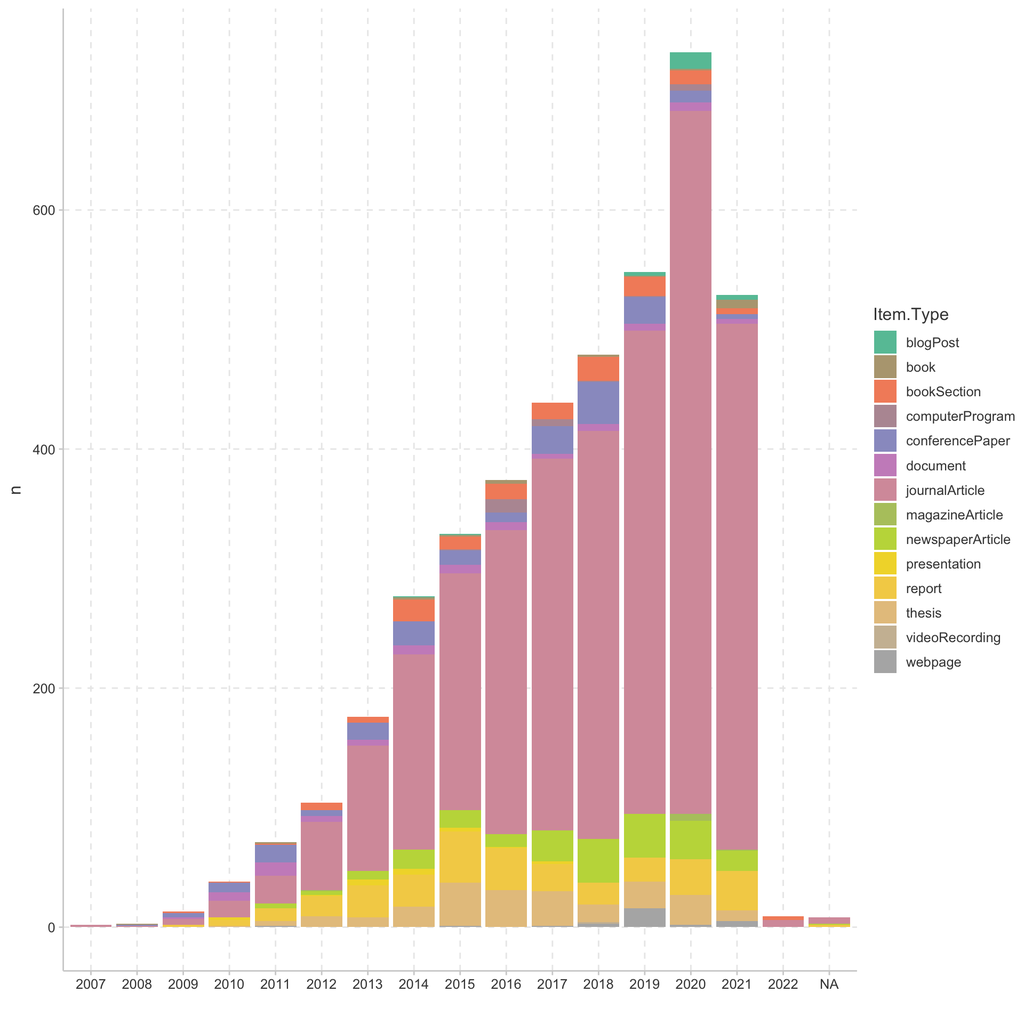

Figure 1.

```r
dat %>%
  count(Publication.Year, Item.Type) -> count_year

nb.cols <- 14
mycolors <- colorRampPalette(brewer.pal(8, "Set2"))(nb.cols)

ggplot(count_year, aes(as.character(Publication.Year), n, fill=Item.Type)) +
  geom_bar(stat="identity") + #, position="dodge"
  xlab("") +
  scale_fill_manual(values = mycolors)
```

Subset by year - for piloting the code only use data from 2020.

```r
dat_2020 <- dat %>% filter(Publication.Year == 2020)
dim(dat_2020)
```

Subset journal articles.

```r
dat_articles <- dat_2020 %>% filter(Item.Type == "journalArticle") %>% select( c(Key:Manual.Tags))
dim(dat_articles)

#remove remaining completely empty columns
dat_articles %>% select_if(function(x){!all(is.na(x))}) -> dat_articles

#table(dat_articles$Manual.Tags, useNA = "always")
```

Make a data missingnes plot.

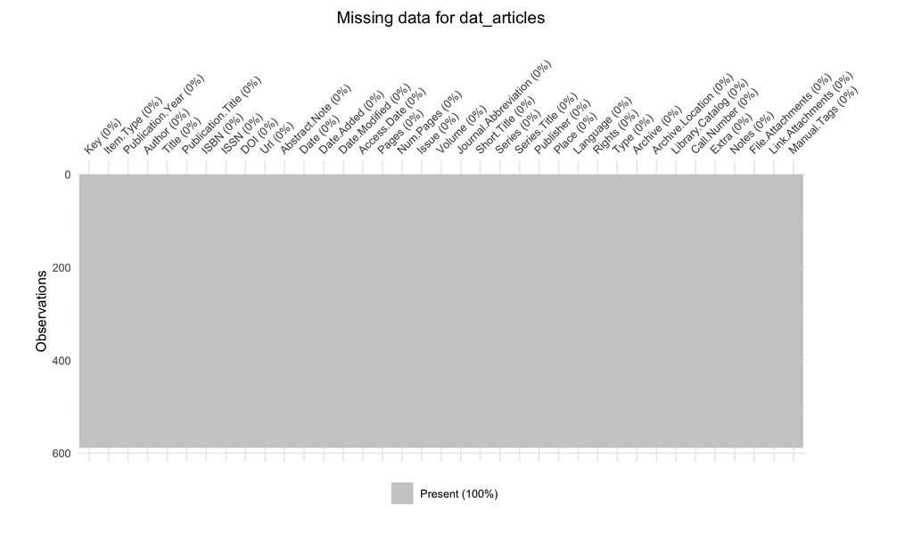

Figure. Distribution of missing values in journal articles data subset

```r
vis_miss(dat_articles) +
  theme(plot.title = element_text(hjust = 0.5, vjust = 3),
        plot.margin = margin(t = 0.5, r = 3, b = 1, l = 1, unit = "cm")) +
  ggtitle("Missing data for dat_articles") #no missing values
```

Data is complete, however this needs further checking (e.g. special characters used for missing values).